# Risk Factor Analysis

## Outcome Variable

**Outcome Variable:** wast_rec90d

## Predictor Variables

**Intervention Variable:** mbmi

**Adjustment Set:**

unadjusted

## Stratifying Variables

The analysis was stratified on these variable(s):

- agecat
- studyid
- country

## Data Summary

| agecat | studyid | country | mbmi | wast_rec90d | n_cell | n |
| --- | --- | --- | --- | --- | --- | --- |
| 0-24 months | iLiNS-Zinc | BURKINA FASO | Normal weight | 0 | 624 | 794 |
| 0-24 months | iLiNS-Zinc | BURKINA FASO | Normal weight | 1 | 27 | 794 |
| 0-24 months | iLiNS-Zinc | BURKINA FASO | Underweight | 0 | 135 | 794 |
| 0-24 months | iLiNS-Zinc | BURKINA FASO | Underweight | 1 | 8 | 794 |
| 0-24 months | JiVitA-3 | BANGLADESH | Normal weight | 0 | 2531 | 7538 |
| 0-24 months | JiVitA-3 | BANGLADESH | Normal weight | 1 | 1949 | 7538 |
| 0-24 months | JiVitA-3 | BANGLADESH | Underweight | 0 | 1821 | 7538 |
| 0-24 months | JiVitA-3 | BANGLADESH | Underweight | 1 | 1237 | 7538 |
| 0-24 months | LCNI-5 | MALAWI | Normal weight | 0 | 42 | 78 |
| 0-24 months | LCNI-5 | MALAWI | Normal weight | 1 | 6 | 78 |
| 0-24 months | LCNI-5 | MALAWI | Underweight | 0 | 23 | 78 |
| 0-24 months | LCNI-5 | MALAWI | Underweight | 1 | 7 | 78 |
| 0-24 months | MAL-ED | BANGLADESH | Normal weight | 0 | 30 | 122 |
| 0-24 months | MAL-ED | BANGLADESH | Normal weight | 1 | 64 | 122 |
| 0-24 months | MAL-ED | BANGLADESH | Underweight | 0 | 13 | 122 |
| 0-24 months | MAL-ED | BANGLADESH | Underweight | 1 | 15 | 122 |
| 0-24 months | MAL-ED | BRAZIL | Normal weight | 0 | 6 | 23 |
| 0-24 months | MAL-ED | BRAZIL | Normal weight | 1 | 15 | 23 |
| 0-24 months | MAL-ED | BRAZIL | Underweight | 0 | 0 | 23 |
| 0-24 months | MAL-ED | BRAZIL | Underweight | 1 | 2 | 23 |
| 0-24 months | MAL-ED | INDIA | Normal weight | 0 | 49 | 178 |
| 0-24 months | MAL-ED | INDIA | Normal weight | 1 | 82 | 178 |
| 0-24 months | MAL-ED | INDIA | Underweight | 0 | 21 | 178 |
| 0-24 months | MAL-ED | INDIA | Underweight | 1 | 26 | 178 |
| 0-24 months | MAL-ED | NEPAL | Normal weight | 0 | 20 | 98 |
| 0-24 months | MAL-ED | NEPAL | Normal weight | 1 | 78 | 98 |
| 0-24 months | MAL-ED | NEPAL | Underweight | 0 | 0 | 98 |
| 0-24 months | MAL-ED | NEPAL | Underweight | 1 | 0 | 98 |
| 0-24 months | MAL-ED | PERU | Normal weight | 0 | 5 | 35 |
| 0-24 months | MAL-ED | PERU | Normal weight | 1 | 26 | 35 |

[output cut: 170 more lines]

The following strata were considered:

- agecat: 0-24 months, studyid: iLiNS-Zinc, country: BURKINA FASO
- agecat: 0-24 months, studyid: JiVitA-3, country: BANGLADESH
- agecat: 0-24 months, studyid: LCNI-5, country: MALAWI
- agecat: 0-24 months, studyid: MAL-ED, country: BANGLADESH
- agecat: 0-24 months, studyid: MAL-ED, country: BRAZIL
- agecat: 0-24 months, studyid: MAL-ED, country: INDIA
- agecat: 0-24 months, studyid: MAL-ED, country: NEPAL
- agecat: 0-24 months, studyid: MAL-ED, country: PERU
- agecat: 0-24 months, studyid: MAL-ED, country: SOUTH AFRICA
- agecat: 0-24 months, studyid: MAL-ED, country: TANZANIA, UNITED REPUBLIC OF
- agecat: 0-24 months, studyid: NIH-Birth, country: BANGLADESH
- agecat: 0-24 months, studyid: NIH-Crypto, country: BANGLADESH
- agecat: 0-24 months, studyid: PROBIT, country: BELARUS
- agecat: 0-24 months, studyid: PROVIDE, country: BANGLADESH
- agecat: 0-24 months, studyid: SAS-CompFeed, country: INDIA
- agecat: 0-24 months, studyid: TanzaniaChild2, country: TANZANIA, UNITED REPUBLIC OF
- agecat: 0-24 months, studyid: ZVITAMBO, country: ZIMBABWE
- agecat: 0-6 months, studyid: JiVitA-3, country: BANGLADESH
- agecat: 0-6 months, studyid: LCNI-5, country: MALAWI
- agecat: 0-6 months, studyid: MAL-ED, country: BANGLADESH
- agecat: 0-6 months, studyid: MAL-ED, country: BRAZIL
- agecat: 0-6 months, studyid: MAL-ED, country: INDIA
- agecat: 0-6 months, studyid: MAL-ED, country: NEPAL
- agecat: 0-6 months, studyid: MAL-ED, country: PERU
- agecat: 0-6 months, studyid: MAL-ED, country: SOUTH AFRICA
- agecat: 0-6 months, studyid: MAL-ED, country: TANZANIA, UNITED REPUBLIC OF
- agecat: 0-6 months, studyid: NIH-Birth, country: BANGLADESH
- agecat: 0-6 months, studyid: NIH-Crypto, country: BANGLADESH
- agecat: 0-6 months, studyid: PROBIT, country: BELARUS
- agecat: 0-6 months, studyid: PROVIDE, country: BANGLADESH
- agecat: 0-6 months, studyid: SAS-CompFeed, country: INDIA
- agecat: 0-6 months, studyid: TanzaniaChild2, country: TANZANIA, UNITED REPUBLIC OF
- agecat: 0-6 months, studyid: ZVITAMBO, country: ZIMBABWE
- agecat: 6-24 months, studyid: iLiNS-Zinc, country: BURKINA FASO
- agecat: 6-24 months, studyid: JiVitA-3, country: BANGLADESH
- agecat: 6-24 months, studyid: LCNI-5, country: MALAWI
- agecat: 6-24 months, studyid: MAL-ED, country: BANGLADESH
- agecat: 6-24 months, studyid: MAL-ED, country: BRAZIL
- agecat: 6-24 months, studyid: MAL-ED, country: INDIA
- agecat: 6-24 months, studyid: MAL-ED, country: NEPAL
- agecat: 6-24 months, studyid: MAL-ED, country: PERU
- agecat: 6-24 months, studyid: MAL-ED, country: SOUTH AFRICA
- agecat: 6-24 months, studyid: MAL-ED, country: TANZANIA, UNITED REPUBLIC OF
- agecat: 6-24 months, studyid: NIH-Birth, country: BANGLADESH
- agecat: 6-24 months, studyid: NIH-Crypto, country: BANGLADESH
- agecat: 6-24 months, studyid: PROBIT, country: BELARUS
- agecat: 6-24 months, studyid: PROVIDE, country: BANGLADESH
- agecat: 6-24 months, studyid: SAS-CompFeed, country: INDIA
- agecat: 6-24 months, studyid: TanzaniaChild2, country: TANZANIA, UNITED REPUBLIC OF
- agecat: 6-24 months, studyid: ZVITAMBO, country: ZIMBABWE

### Dropped Strata

Some strata were dropped due to rare outcomes:

- agecat: 0-24 months, studyid: MAL-ED, country: BRAZIL
- agecat: 0-24 months, studyid: MAL-ED, country: NEPAL
- agecat: 0-24 months, studyid: MAL-ED, country: PERU
- agecat: 0-24 months, studyid: MAL-ED, country: SOUTH AFRICA
- agecat: 0-24 months, studyid: MAL-ED, country: TANZANIA, UNITED REPUBLIC OF
- agecat: 0-6 months, studyid: LCNI-5, country: MALAWI
- agecat: 0-6 months, studyid: MAL-ED, country: BRAZIL
- agecat: 0-6 months, studyid: MAL-ED, country: NEPAL
- agecat: 0-6 months, studyid: MAL-ED, country: PERU
- agecat: 0-6 months, studyid: MAL-ED, country: SOUTH AFRICA
- agecat: 0-6 months, studyid: MAL-ED, country: TANZANIA, UNITED REPUBLIC OF
- agecat: 0-6 months, studyid: NIH-Crypto, country: BANGLADESH
- agecat: 0-6 months, studyid: TanzaniaChild2, country: TANZANIA, UNITED REPUBLIC OF
- agecat: 6-24 months, studyid: JiVitA-3, country: BANGLADESH
- agecat: 6-24 months, studyid: MAL-ED, country: BRAZIL
- agecat: 6-24 months, studyid: MAL-ED, country: NEPAL
- agecat: 6-24 months, studyid: MAL-ED, country: PERU
- agecat: 6-24 months, studyid: MAL-ED, country: SOUTH AFRICA
- agecat: 6-24 months, studyid: MAL-ED, country: TANZANIA, UNITED REPUBLIC OF
- agecat: 6-24 months, studyid: NIH-Crypto, country: BANGLADESH
- agecat: 6-24 months, studyid: PROBIT, country: BELARUS
- agecat: 6-24 months, studyid: TanzaniaChild2, country: TANZANIA, UNITED REPUBLIC OF

## Methods Detail

We’re interested in the causal parameters $E[Y_a]$ for all values of $a \in \mathcal{A}$. These parameters represent the mean outcome if, possibly contrary to fact, we intervened to set all units to have $A=a$. Under the randomization and positivity assumptions, these are identified by the statistical parameters $\psi_a=E_W[E_{Y|A,W}(Y|A=a,W)]$. In addition, we’re interested in the mean of $Y$, $E[Y]$ under no intervention (the observed mean). We will estimate these parameters by using SuperLearner to fit the relevant likelihood factors – $E_{Y|A,W}(Y|A=a,W)$ and $p(A=a|W)$, and then updating our likelihood fit using a joint TMLE.

For unadjusted analyses ($W=\{\}$), initial likelihoods were estimated using Lrnr_glm to estimate the simple $E(Y|A)$ and Lrnr_mean to estimate $p(A)$. For adjusted analyses, a small library containing Lrnr_glmnet, Lrnr_xgboost, and Lrnr_mean was used.

Having estimated these parameters, we will then use the delta method to estimate relative risks and attributable risks relative to a prespecified baseline level of $A$.

# Results Detail

## Results Plots

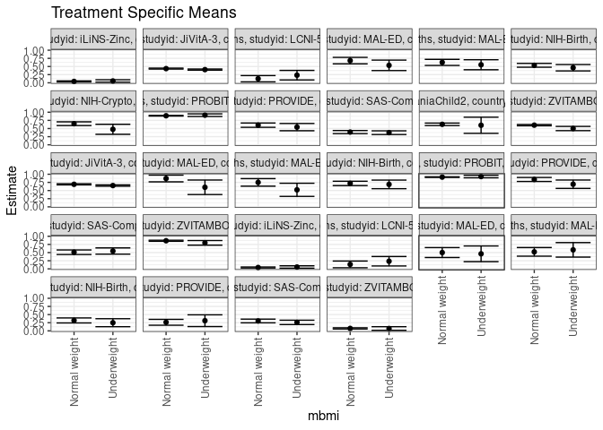

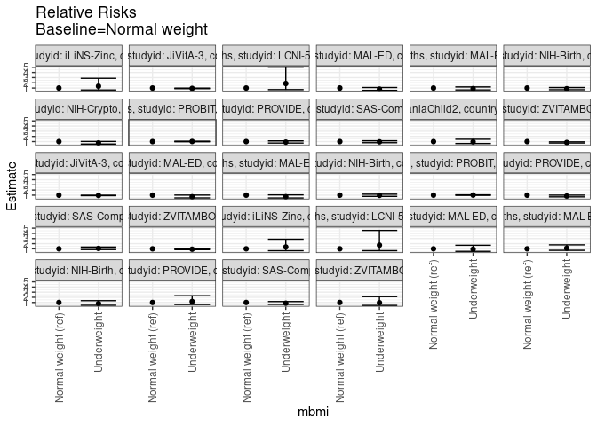

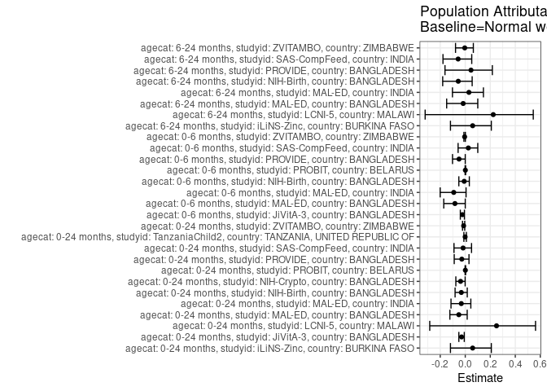

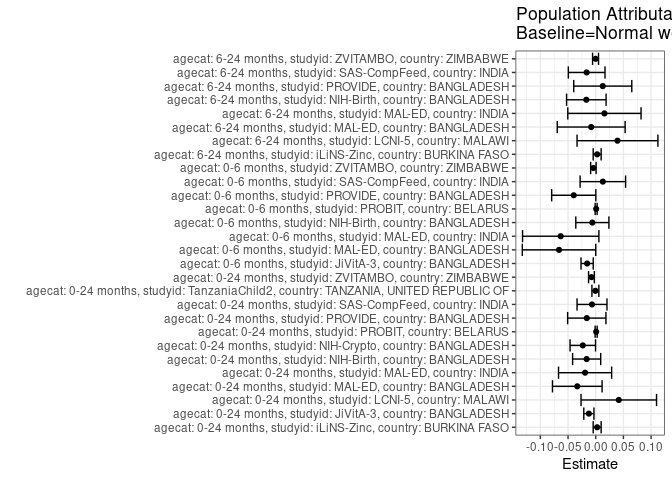

## Results Table

### Parameter: TSM

| agecat | studyid | country | intervention_level | baseline_level | estimate | ci_lower | ci_upper |
| --- | --- | --- | --- | --- | --- | --- | --- |
| 0-24 months | iLiNS-Zinc | BURKINA FASO | Normal weight | NA | 0.0414747 | 0.0260799 | 0.0568695 |
| 0-24 months | iLiNS-Zinc | BURKINA FASO | Underweight | NA | 0.0559441 | 0.0191705 | 0.0927176 |
| 0-24 months | JiVitA-3 | BANGLADESH | Normal weight | NA | 0.4350446 | 0.4204788 | 0.4496104 |
| 0-24 months | JiVitA-3 | BANGLADESH | Underweight | NA | 0.4045128 | 0.3872303 | 0.4217952 |
| 0-24 months | LCNI-5 | MALAWI | Normal weight | NA | 0.1250000 | 0.0290888 | 0.2209112 |
| 0-24 months | LCNI-5 | MALAWI | Underweight | NA | 0.2333333 | 0.0868920 | 0.3797747 |
| 0-24 months | MAL-ED | BANGLADESH | Normal weight | NA | 0.6808511 | 0.5815527 | 0.7801494 |
| 0-24 months | MAL-ED | BANGLADESH | Underweight | NA | 0.5357143 | 0.3749740 | 0.6964546 |
| 0-24 months | MAL-ED | INDIA | Normal weight | NA | 0.6259542 | 0.5328629 | 0.7190455 |
| 0-24 months | MAL-ED | INDIA | Underweight | NA | 0.5531915 | 0.3998138 | 0.7065691 |
| 0-24 months | NIH-Birth | BANGLADESH | Normal weight | NA | 0.5365854 | 0.4780574 | 0.5951134 |
| 0-24 months | NIH-Birth | BANGLADESH | Underweight | NA | 0.4623656 | 0.3638762 | 0.5608549 |
| 0-24 months | NIH-Crypto | BANGLADESH | Normal weight | NA | 0.6479401 | 0.5908723 | 0.7050078 |
| 0-24 months | NIH-Crypto | BANGLADESH | Underweight | NA | 0.4761905 | 0.3221133 | 0.6302677 |
| 0-24 months | PROBIT | BELARUS | Normal weight | NA | 0.8918704 | 0.8820518 | 0.9016889 |
| 0-24 months | PROBIT | BELARUS | Underweight | NA | 0.9096045 | 0.8697554 | 0.9494537 |
| 0-24 months | PROVIDE | BANGLADESH | Normal weight | NA | 0.6036036 | 0.5376831 | 0.6695241 |
| 0-24 months | PROVIDE | BANGLADESH | Underweight | NA | 0.5432099 | 0.4319946 | 0.6544251 |
| 0-24 months | SAS-CompFeed | INDIA | Normal weight | NA | 0.3911205 | 0.3433971 | 0.4388439 |
| 0-24 months | SAS-CompFeed | INDIA | Underweight | NA | 0.3726937 | 0.3160952 | 0.4292922 |
| 0-24 months | TanzaniaChild2 | TANZANIA, UNITED REPUBLIC OF | Normal weight | NA | 0.6288210 | 0.5904220 | 0.6672199 |
| 0-24 months | TanzaniaChild2 | TANZANIA, UNITED REPUBLIC OF | Underweight | NA | 0.6000000 | 0.3523180 | 0.8476820 |
| 0-24 months | ZVITAMBO | ZIMBABWE | Normal weight | NA | 0.6033721 | 0.5840502 | 0.6226941 |
| 0-24 months | ZVITAMBO | ZIMBABWE | Underweight | NA | 0.5000000 | 0.4345373 | 0.5654627 |
| 0-6 months | JiVitA-3 | BANGLADESH | Normal weight | NA | 0.6913799 | 0.6743343 | 0.7084256 |
| 0-6 months | JiVitA-3 | BANGLADESH | Underweight | NA | 0.6527704 | 0.6313237 | 0.6742172 |
| 0-6 months | MAL-ED | BANGLADESH | Normal weight | NA | 0.8695652 | 0.7664853 | 0.9726451 |
| 0-6 months | MAL-ED | BANGLADESH | Underweight | NA | 0.6000000 | 0.3773683 | 0.8226317 |
| 0-6 months | MAL-ED | INDIA | Normal weight | NA | 0.7500000 | 0.6348133 | 0.8651867 |
| 0-6 months | MAL-ED | INDIA | Underweight | NA | 0.5217391 | 0.3201168 | 0.7233615 |
| 0-6 months | NIH-Birth | BANGLADESH | Normal weight | NA | 0.7191011 | 0.6526289 | 0.7855734 |
| 0-6 months | NIH-Birth | BANGLADESH | Underweight | NA | 0.6888889 | 0.5565481 | 0.8212297 |
| 0-6 months | PROBIT | BELARUS | Normal weight | NA | 0.9124829 | 0.9032553 | 0.9217104 |
| 0-6 months | PROBIT | BELARUS | Underweight | NA | 0.9298246 | 0.8911173 | 0.9685318 |
| 0-6 months | PROVIDE | BANGLADESH | Normal weight | NA | 0.8396947 | 0.7787342 | 0.9006551 |
| 0-6 months | PROVIDE | BANGLADESH | Underweight | NA | 0.6938776 | 0.5649886 | 0.8227665 |
| 0-6 months | SAS-CompFeed | INDIA | Normal weight | NA | 0.5100000 | 0.4401675 | 0.5798325 |
| 0-6 months | SAS-CompFeed | INDIA | Underweight | NA | 0.5471698 | 0.4514150 | 0.6429246 |
| 0-6 months | ZVITAMBO | ZIMBABWE | Normal weight | NA | 0.8623579 | 0.8458945 | 0.8788213 |
| 0-6 months | ZVITAMBO | ZIMBABWE | Underweight | NA | 0.7983193 | 0.7270042 | 0.8696344 |
| 6-24 months | iLiNS-Zinc | BURKINA FASO | Normal weight | NA | 0.0414747 | 0.0260799 | 0.0568695 |
| 6-24 months | iLiNS-Zinc | BURKINA FASO | Underweight | NA | 0.0559441 | 0.0191705 | 0.0927176 |
| 6-24 months | LCNI-5 | MALAWI | Normal weight | NA | 0.1363636 | 0.0329768 | 0.2397505 |
| 6-24 months | LCNI-5 | MALAWI | Underweight | NA | 0.2333333 | 0.0877343 | 0.3789324 |
| 6-24 months | MAL-ED | BANGLADESH | Normal weight | NA | 0.5000000 | 0.3474407 | 0.6525593 |
| 6-24 months | MAL-ED | BANGLADESH | Underweight | NA | 0.4615385 | 0.2210093 | 0.7020676 |
| 6-24 months | MAL-ED | INDIA | Normal weight | NA | 0.5211268 | 0.3887216 | 0.6535319 |
| 6-24 months | MAL-ED | INDIA | Underweight | NA | 0.5833333 | 0.3604966 | 0.8061700 |
| 6-24 months | NIH-Birth | BANGLADESH | Normal weight | NA | 0.3200000 | 0.2435094 | 0.3964906 |
| 6-24 months | NIH-Birth | BANGLADESH | Underweight | NA | 0.2500000 | 0.1270597 | 0.3729403 |
| 6-24 months | PROVIDE | BANGLADESH | Normal weight | NA | 0.2637363 | 0.1740755 | 0.3533970 |
| 6-24 months | PROVIDE | BANGLADESH | Underweight | NA | 0.3125000 | 0.1324872 | 0.4925128 |
| 6-24 months | SAS-CompFeed | INDIA | Normal weight | NA | 0.3040293 | 0.2472596 | 0.3607990 |
| 6-24 months | SAS-CompFeed | INDIA | Underweight | NA | 0.2606061 | 0.1936822 | 0.3275299 |
| 6-24 months | ZVITAMBO | ZIMBABWE | Normal weight | NA | 0.0756098 | 0.0575698 | 0.0936498 |
| 6-24 months | ZVITAMBO | ZIMBABWE | Underweight | NA | 0.0722892 | 0.0168678 | 0.1277105 |

### Parameter: E(Y)

| agecat | studyid | country | intervention_level | baseline_level | estimate | ci_lower | ci_upper |
| --- | --- | --- | --- | --- | --- | --- | --- |
| 0-24 months | iLiNS-Zinc | BURKINA FASO | NA | NA | 0.0440806 | 0.0298222 | 0.0583390 |
| 0-24 months | JiVitA-3 | BANGLADESH | NA | NA | 0.4226585 | 0.4115120 | 0.4338051 |
| 0-24 months | LCNI-5 | MALAWI | NA | NA | 0.1666667 | 0.0842830 | 0.2490503 |
| 0-24 months | MAL-ED | BANGLADESH | NA | NA | 0.6475410 | 0.5613826 | 0.7336993 |
| 0-24 months | MAL-ED | INDIA | NA | NA | 0.6067416 | 0.5268346 | 0.6866486 |
| 0-24 months | NIH-Birth | BANGLADESH | NA | NA | 0.5201900 | 0.4695846 | 0.5707955 |
| 0-24 months | NIH-Crypto | BANGLADESH | NA | NA | 0.6245955 | 0.5705077 | 0.6786833 |
| 0-24 months | PROBIT | BELARUS | NA | NA | 0.8926668 | 0.8831189 | 0.9022148 |
| 0-24 months | PROVIDE | BANGLADESH | NA | NA | 0.5874587 | 0.5306185 | 0.6442990 |
| 0-24 months | SAS-CompFeed | INDIA | NA | NA | 0.3844086 | 0.3477135 | 0.4211037 |
| 0-24 months | TanzaniaChild2 | TANZANIA, UNITED REPUBLIC OF | NA | NA | 0.6282051 | 0.5902579 | 0.6661523 |
| 0-24 months | ZVITAMBO | ZIMBABWE | NA | NA | 0.5956183 | 0.5770555 | 0.6141810 |
| 0-6 months | JiVitA-3 | BANGLADESH | NA | NA | 0.6758591 | 0.6624976 | 0.6892206 |
| 0-6 months | MAL-ED | BANGLADESH | NA | NA | 0.8032787 | 0.7044023 | 0.9021551 |
| 0-6 months | MAL-ED | INDIA | NA | NA | 0.6867470 | 0.5837430 | 0.7897510 |
| 0-6 months | NIH-Birth | BANGLADESH | NA | NA | 0.7130045 | 0.6535890 | 0.7724200 |
| 0-6 months | PROBIT | BELARUS | NA | NA | 0.9132600 | 0.9042761 | 0.9222438 |
| 0-6 months | PROVIDE | BANGLADESH | NA | NA | 0.8000000 | 0.7425836 | 0.8574164 |
| 0-6 months | SAS-CompFeed | INDIA | NA | NA | 0.5228758 | 0.4664267 | 0.5793250 |
| 0-6 months | ZVITAMBO | ZIMBABWE | NA | NA | 0.8581006 | 0.8420009 | 0.8742002 |
| 6-24 months | iLiNS-Zinc | BURKINA FASO | NA | NA | 0.0440806 | 0.0298222 | 0.0583390 |
| 6-24 months | LCNI-5 | MALAWI | NA | NA | 0.1756757 | 0.0897916 | 0.2615597 |
| 6-24 months | MAL-ED | BANGLADESH | NA | NA | 0.4918033 | 0.3610932 | 0.6225134 |
| 6-24 months | MAL-ED | INDIA | NA | NA | 0.5368421 | 0.4223932 | 0.6512910 |
| 6-24 months | NIH-Birth | BANGLADESH | NA | NA | 0.3030303 | 0.2377927 | 0.3682679 |
| 6-24 months | PROVIDE | BANGLADESH | NA | NA | 0.2764228 | 0.1950773 | 0.3577682 |
| 6-24 months | SAS-CompFeed | INDIA | NA | NA | 0.2876712 | 0.2441703 | 0.3311721 |
| 6-24 months | ZVITAMBO | ZIMBABWE | NA | NA | 0.0753045 | 0.0581490 | 0.0924601 |

### Parameter: RR

| agecat | studyid | country | intervention_level | baseline_level | estimate | ci_lower | ci_upper |
| --- | --- | --- | --- | --- | --- | --- | --- |
| 0-24 months | iLiNS-Zinc | BURKINA FASO | Normal weight | Normal weight | 1.0000000 | 1.0000000 | 1.0000000 |
| 0-24 months | iLiNS-Zinc | BURKINA FASO | Underweight | Normal weight | 1.3488733 | 0.6340510 | 2.8695789 |
| 0-24 months | JiVitA-3 | BANGLADESH | Normal weight | Normal weight | 1.0000000 | 1.0000000 | 1.0000000 |
| 0-24 months | JiVitA-3 | BANGLADESH | Underweight | Normal weight | 0.9298190 | 0.8806933 | 0.9816848 |
| 0-24 months | LCNI-5 | MALAWI | Normal weight | Normal weight | 1.0000000 | 1.0000000 | 1.0000000 |
| 0-24 months | LCNI-5 | MALAWI | Underweight | Normal weight | 1.8666667 | 0.6926702 | 5.0304525 |
| 0-24 months | MAL-ED | BANGLADESH | Normal weight | Normal weight | 1.0000000 | 1.0000000 | 1.0000000 |
| 0-24 months | MAL-ED | BANGLADESH | Underweight | Normal weight | 0.7868304 | 0.5636090 | 1.0984601 |
| 0-24 months | MAL-ED | INDIA | Normal weight | Normal weight | 1.0000000 | 1.0000000 | 1.0000000 |
| 0-24 months | MAL-ED | INDIA | Underweight | Normal weight | 0.8837571 | 0.6451836 | 1.2105496 |
| 0-24 months | NIH-Birth | BANGLADESH | Normal weight | Normal weight | 1.0000000 | 1.0000000 | 1.0000000 |
| 0-24 months | NIH-Birth | BANGLADESH | Underweight | Normal weight | 0.8616813 | 0.6782339 | 1.0947472 |
| 0-24 months | NIH-Crypto | BANGLADESH | Normal weight | Normal weight | 1.0000000 | 1.0000000 | 1.0000000 |
| 0-24 months | NIH-Crypto | BANGLADESH | Underweight | Normal weight | 0.7349298 | 0.5254528 | 1.0279170 |
| 0-24 months | PROBIT | BELARUS | Normal weight | Normal weight | 1.0000000 | 1.0000000 | 1.0000000 |
| 0-24 months | PROBIT | BELARUS | Underweight | Normal weight | 1.0198842 | 0.9748391 | 1.0670108 |
| 0-24 months | PROVIDE | BANGLADESH | Normal weight | Normal weight | 1.0000000 | 1.0000000 | 1.0000000 |
| 0-24 months | PROVIDE | BANGLADESH | Underweight | Normal weight | 0.8999447 | 0.7134825 | 1.1351372 |
| 0-24 months | SAS-CompFeed | INDIA | Normal weight | Normal weight | 1.0000000 | 1.0000000 | 1.0000000 |
| 0-24 months | SAS-CompFeed | INDIA | Underweight | Normal weight | 0.9528872 | 0.7841920 | 1.1578721 |
| 0-24 months | TanzaniaChild2 | TANZANIA, UNITED REPUBLIC OF | Normal weight | Normal weight | 1.0000000 | 1.0000000 | 1.0000000 |
| 0-24 months | TanzaniaChild2 | TANZANIA, UNITED REPUBLIC OF | Underweight | Normal weight | 0.9541667 | 0.6286319 | 1.4482784 |
| 0-24 months | ZVITAMBO | ZIMBABWE | Normal weight | Normal weight | 1.0000000 | 1.0000000 | 1.0000000 |
| 0-24 months | ZVITAMBO | ZIMBABWE | Underweight | Normal weight | 0.8286760 | 0.7241726 | 0.9482600 |
| 0-6 months | JiVitA-3 | BANGLADESH | Normal weight | Normal weight | 1.0000000 | 1.0000000 | 1.0000000 |
| 0-6 months | JiVitA-3 | BANGLADESH | Underweight | Normal weight | 0.9441559 | 0.9061588 | 0.9837463 |
| 0-6 months | MAL-ED | BANGLADESH | Normal weight | Normal weight | 1.0000000 | 1.0000000 | 1.0000000 |
| 0-6 months | MAL-ED | BANGLADESH | Underweight | Normal weight | 0.6900000 | 0.4673961 | 1.0186222 |
| 0-6 months | MAL-ED | INDIA | Normal weight | Normal weight | 1.0000000 | 1.0000000 | 1.0000000 |
| 0-6 months | MAL-ED | INDIA | Underweight | Normal weight | 0.6956522 | 0.4589546 | 1.0544223 |
| 0-6 months | NIH-Birth | BANGLADESH | Normal weight | Normal weight | 1.0000000 | 1.0000000 | 1.0000000 |
| 0-6 months | NIH-Birth | BANGLADESH | Underweight | Normal weight | 0.9579861 | 0.7740550 | 1.1856229 |
| 0-6 months | PROBIT | BELARUS | Normal weight | Normal weight | 1.0000000 | 1.0000000 | 1.0000000 |
| 0-6 months | PROBIT | BELARUS | Underweight | Normal weight | 1.0190050 | 0.9762734 | 1.0636069 |
| 0-6 months | PROVIDE | BANGLADESH | Normal weight | Normal weight | 1.0000000 | 1.0000000 | 1.0000000 |
| 0-6 months | PROVIDE | BANGLADESH | Underweight | Normal weight | 0.8263451 | 0.6769325 | 1.0087360 |
| 0-6 months | SAS-CompFeed | INDIA | Normal weight | Normal weight | 1.0000000 | 1.0000000 | 1.0000000 |
| 0-6 months | SAS-CompFeed | INDIA | Underweight | Normal weight | 1.0728820 | 0.8591064 | 1.3398523 |
| 0-6 months | ZVITAMBO | ZIMBABWE | Normal weight | Normal weight | 1.0000000 | 1.0000000 | 1.0000000 |
| 0-6 months | ZVITAMBO | ZIMBABWE | Underweight | Normal weight | 0.9257402 | 0.8449224 | 1.0142883 |
| 6-24 months | iLiNS-Zinc | BURKINA FASO | Normal weight | Normal weight | 1.0000000 | 1.0000000 | 1.0000000 |
| 6-24 months | iLiNS-Zinc | BURKINA FASO | Underweight | Normal weight | 1.3488733 | 0.6340510 | 2.8695789 |
| 6-24 months | LCNI-5 | MALAWI | Normal weight | Normal weight | 1.0000000 | 1.0000000 | 1.0000000 |
| 6-24 months | LCNI-5 | MALAWI | Underweight | Normal weight | 1.7111111 | 0.6408783 | 4.5685760 |
| 6-24 months | MAL-ED | BANGLADESH | Normal weight | Normal weight | 1.0000000 | 1.0000000 | 1.0000000 |
| 6-24 months | MAL-ED | BANGLADESH | Underweight | Normal weight | 0.9230769 | 0.5044974 | 1.6889501 |
| 6-24 months | MAL-ED | INDIA | Normal weight | Normal weight | 1.0000000 | 1.0000000 | 1.0000000 |
| 6-24 months | MAL-ED | INDIA | Underweight | Normal weight | 1.1193694 | 0.7076813 | 1.7705538 |
| 6-24 months | NIH-Birth | BANGLADESH | Normal weight | Normal weight | 1.0000000 | 1.0000000 | 1.0000000 |
| 6-24 months | NIH-Birth | BANGLADESH | Underweight | Normal weight | 0.7812500 | 0.4520464 | 1.3501968 |
| 6-24 months | PROVIDE | BANGLADESH | Normal weight | Normal weight | 1.0000000 | 1.0000000 | 1.0000000 |
| 6-24 months | PROVIDE | BANGLADESH | Underweight | Normal weight | 1.1848958 | 0.6069821 | 2.3130472 |
| 6-24 months | SAS-CompFeed | INDIA | Normal weight | Normal weight | 1.0000000 | 1.0000000 | 1.0000000 |
| 6-24 months | SAS-CompFeed | INDIA | Underweight | Normal weight | 0.8571742 | 0.6239877 | 1.1775031 |
| 6-24 months | ZVITAMBO | ZIMBABWE | Normal weight | Normal weight | 1.0000000 | 1.0000000 | 1.0000000 |
| 6-24 months | ZVITAMBO | ZIMBABWE | Underweight | Normal weight | 0.9560824 | 0.4283383 | 2.1340459 |

### Parameter: PAR

| agecat | studyid | country | intervention_level | baseline_level | estimate | ci_lower | ci_upper |
| --- | --- | --- | --- | --- | --- | --- | --- |
| 0-24 months | iLiNS-Zinc | BURKINA FASO | Normal weight | NA | 0.0026060 | -0.0045811 | 0.0097930 |
| 0-24 months | JiVitA-3 | BANGLADESH | Normal weight | NA | -0.0123861 | -0.0215641 | -0.0032081 |
| 0-24 months | LCNI-5 | MALAWI | Normal weight | NA | 0.0416667 | -0.0265326 | 0.1098659 |
| 0-24 months | MAL-ED | BANGLADESH | Normal weight | NA | -0.0333101 | -0.0781269 | 0.0115068 |
| 0-24 months | MAL-ED | INDIA | Normal weight | NA | -0.0192126 | -0.0671731 | 0.0287479 |
| 0-24 months | NIH-Birth | BANGLADESH | Normal weight | NA | -0.0163953 | -0.0417725 | 0.0089818 |
| 0-24 months | NIH-Crypto | BANGLADESH | Normal weight | NA | -0.0233446 | -0.0463504 | -0.0003388 |
| 0-24 months | PROBIT | BELARUS | Normal weight | NA | 0.0007965 | -0.0010544 | 0.0026473 |
| 0-24 months | PROVIDE | BANGLADESH | Normal weight | NA | -0.0161449 | -0.0507237 | 0.0184339 |
| 0-24 months | SAS-CompFeed | INDIA | Normal weight | NA | -0.0067119 | -0.0337199 | 0.0202961 |
| 0-24 months | TanzaniaChild2 | TANZANIA, UNITED REPUBLIC OF | Normal weight | NA | -0.0006158 | -0.0068812 | 0.0056495 |
| 0-24 months | ZVITAMBO | ZIMBABWE | Normal weight | NA | -0.0077539 | -0.0129369 | -0.0025708 |
| 0-6 months | JiVitA-3 | BANGLADESH | Normal weight | NA | -0.0155208 | -0.0265468 | -0.0044947 |
| 0-6 months | MAL-ED | BANGLADESH | Normal weight | NA | -0.0662865 | -0.1326161 | 0.0000431 |
| 0-6 months | MAL-ED | INDIA | Normal weight | NA | -0.0632530 | -0.1321914 | 0.0056853 |
| 0-6 months | NIH-Birth | BANGLADESH | Normal weight | NA | -0.0060966 | -0.0360118 | 0.0238185 |
| 0-6 months | PROBIT | BELARUS | Normal weight | NA | 0.0007771 | -0.0010097 | 0.0025639 |
| 0-6 months | PROVIDE | BANGLADESH | Normal weight | NA | -0.0396947 | -0.0795722 | 0.0001829 |
| 0-6 months | SAS-CompFeed | INDIA | Normal weight | NA | 0.0128758 | -0.0281999 | 0.0539515 |
| 0-6 months | ZVITAMBO | ZIMBABWE | Normal weight | NA | -0.0042573 | -0.0091744 | 0.0006598 |
| 6-24 months | iLiNS-Zinc | BURKINA FASO | Normal weight | NA | 0.0026060 | -0.0045811 | 0.0097930 |
| 6-24 months | LCNI-5 | MALAWI | Normal weight | NA | 0.0393120 | -0.0337215 | 0.1123456 |
| 6-24 months | MAL-ED | BANGLADESH | Normal weight | NA | -0.0081967 | -0.0695069 | 0.0531135 |
| 6-24 months | MAL-ED | INDIA | Normal weight | NA | 0.0157153 | -0.0504677 | 0.0818984 |
| 6-24 months | NIH-Birth | BANGLADESH | Normal weight | NA | -0.0169697 | -0.0526533 | 0.0187139 |
| 6-24 months | PROVIDE | BANGLADESH | Normal weight | NA | 0.0126865 | -0.0397556 | 0.0651286 |
| 6-24 months | SAS-CompFeed | INDIA | Normal weight | NA | -0.0163581 | -0.0494776 | 0.0167614 |
| 6-24 months | ZVITAMBO | ZIMBABWE | Normal weight | NA | -0.0003052 | -0.0056628 | 0.0050524 |

### Parameter: PAF

| agecat | studyid | country | intervention_level | baseline_level | estimate | ci_lower | ci_upper |
| --- | --- | --- | --- | --- | --- | --- | --- |
| 0-24 months | iLiNS-Zinc | BURKINA FASO | Normal weight | NA | 0.0591178 | -0.1182440 | 0.2083487 |
| 0-24 months | JiVitA-3 | BANGLADESH | Normal weight | NA | -0.0293052 | -0.0512506 | -0.0078180 |
| 0-24 months | LCNI-5 | MALAWI | Normal weight | NA | 0.2500000 | -0.2838955 | 0.5618802 |
| 0-24 months | MAL-ED | BANGLADESH | Normal weight | NA | -0.0514409 | -0.1229364 | 0.0155026 |
| 0-24 months | MAL-ED | INDIA | Normal weight | NA | -0.0316653 | -0.1139484 | 0.0445400 |
| 0-24 months | NIH-Birth | BANGLADESH | Normal weight | NA | -0.0315180 | -0.0812990 | 0.0159712 |
| 0-24 months | NIH-Crypto | BANGLADESH | Normal weight | NA | -0.0373756 | -0.0752824 | -0.0008051 |
| 0-24 months | PROBIT | BELARUS | Normal weight | NA | 0.0008923 | -0.0011838 | 0.0029640 |
| 0-24 months | PROVIDE | BANGLADESH | Normal weight | NA | -0.0274825 | -0.0881844 | 0.0298332 |
| 0-24 months | SAS-CompFeed | INDIA | Normal weight | NA | -0.0174603 | -0.0900408 | 0.0502874 |
| 0-24 months | TanzaniaChild2 | TANZANIA, UNITED REPUBLIC OF | Normal weight | NA | -0.0009803 | -0.0110044 | 0.0089444 |
| 0-24 months | ZVITAMBO | ZIMBABWE | Normal weight | NA | -0.0130182 | -0.0217632 | -0.0043481 |
| 0-6 months | JiVitA-3 | BANGLADESH | Normal weight | NA | -0.0229645 | -0.0394308 | -0.0067591 |
| 0-6 months | MAL-ED | BANGLADESH | Normal weight | NA | -0.0825200 | -0.1719002 | 0.0000433 |
| 0-6 months | MAL-ED | INDIA | Normal weight | NA | -0.0921053 | -0.2004799 | 0.0064857 |
| 0-6 months | NIH-Birth | BANGLADESH | Normal weight | NA | -0.0085506 | -0.0513998 | 0.0325522 |
| 0-6 months | PROBIT | BELARUS | Normal weight | NA | 0.0008509 | -0.0011079 | 0.0028059 |
| 0-6 months | PROVIDE | BANGLADESH | Normal weight | NA | -0.0496183 | -0.1017453 | 0.0000424 |
| 0-6 months | SAS-CompFeed | INDIA | Normal weight | NA | 0.0246250 | -0.0572330 | 0.1001450 |
| 0-6 months | ZVITAMBO | ZIMBABWE | Normal weight | NA | -0.0049613 | -0.0107160 | 0.0007606 |
| 6-24 months | iLiNS-Zinc | BURKINA FASO | Normal weight | NA | 0.0591178 | -0.1182440 | 0.2083487 |
| 6-24 months | LCNI-5 | MALAWI | Normal weight | NA | 0.2237762 | -0.3205992 | 0.5437500 |
| 6-24 months | MAL-ED | BANGLADESH | Normal weight | NA | -0.0166667 | -0.1486245 | 0.1001314 |
| 6-24 months | MAL-ED | INDIA | Normal weight | NA | 0.0292737 | -0.1023828 | 0.1452066 |
| 6-24 months | NIH-Birth | BANGLADESH | Normal weight | NA | -0.0560000 | -0.1803315 | 0.0552349 |
| 6-24 months | PROVIDE | BANGLADESH | Normal weight | NA | 0.0458953 | -0.1620130 | 0.2166045 |
| 6-24 months | SAS-CompFeed | INDIA | Normal weight | NA | -0.0568638 | -0.1780787 | 0.0518791 |
| 6-24 months | ZVITAMBO | ZIMBABWE | Normal weight | NA | -0.0040531 | -0.0777733 | 0.0646246 |